# IODS course project

Johanna Liuhanen

# Introduction to Open Data Science - Course Project

# About the project

```r
# This is a so-called "R chunk" where you can write R code.

date()
```

```
## [1] "Mon Dec 13 00:15:51 2021"
```

I’m really excited about this course, although it seems quite challenging at the moment! All these technical details and different programs! But I’m happy to learn new things and methods, and I hope that during this course I will learn to use Git (and understand what it is..) and Rmarkdown. I have been using R for quite some time, but not so much Rstudio (and never RMarkdown).

Here is address to my GitHub repository:

https://github.com/jliuhanen/IODS-project

# Chapter 2: Regression and model validation

```r
date()
```

```
## [1] "Mon Dec 13 00:15:51 2021"
```

```r
learning2014 <- read.table("Learning2014", header=T, sep=" ", stringsAsFactors=TRUE)
dim(learning2014)
```

```
## [1] 166   7
```

```r
str(learning2014)
```

```
## 'data.frame':    166 obs. of  7 variables:
##  $ gender  : Factor w/ 2 levels "F","M": 1 2 1 2 2 1 2 1 2 1 ...
##  $ age     : int  53 55 49 53 49 38 50 37 37 42 ...
##  $ attitude: int  37 31 25 35 37 38 35 29 38 21 ...
##  $ points  : int  25 12 24 10 22 21 21 31 24 26 ...
##  $ deep    : num  3.58 2.92 3.5 3.5 3.67 ...
##  $ stra    : num  3.38 2.75 3.62 3.12 3.62 ...
##  $ surf    : num  2.58 3.17 2.25 2.25 2.83 ...
```

The data set (“learning2014”) used in the following analyses is from an international survey of “Approaches to learning”, which was collected in 2014-2015. The original data contained 183 observations on several variables, but the data set used in the following analyses contains 166 observations on 7 variables; 17 observations that had a value of 0 on the variable “points”, were dropped out. The 7 variables include gender (a factor with two levels, “M” and “F”), age, attitude (reflecting global attitude towards statistics), points (exam points), and three numerical variables: deep, stra and surf, which reflect different learning strategies and attitudes (deep, surface, strategy). Deep, stra and surf have been composed of several sub-questions by taking a mean of all the relevant questions related to each of these scales.

```r
library("ggplot2")
library("GGally")
summary(learning2014)
```

```
##  gender       age           attitude         points           deep
##  F:110   Min.   :17.00   Min.   :14.00   Min.   : 7.00   Min.   :1.583
##  M: 56   1st Qu.:21.00   1st Qu.:26.00   1st Qu.:19.00   1st Qu.:3.333
##          Median :22.00   Median :32.00   Median :23.00   Median :3.667
##          Mean   :25.51   Mean   :31.43   Mean   :22.72   Mean   :3.680
##          3rd Qu.:27.00   3rd Qu.:37.00   3rd Qu.:27.75   3rd Qu.:4.083
##          Max.   :55.00   Max.   :50.00   Max.   :33.00   Max.   :4.917
##       stra            surf
##  Min.   :1.250   Min.   :1.583
##  1st Qu.:2.625   1st Qu.:2.417
##  Median :3.188   Median :2.833
##  Mean   :3.121   Mean   :2.787
##  3rd Qu.:3.625   3rd Qu.:3.167
##  Max.   :5.000   Max.   :4.333
```

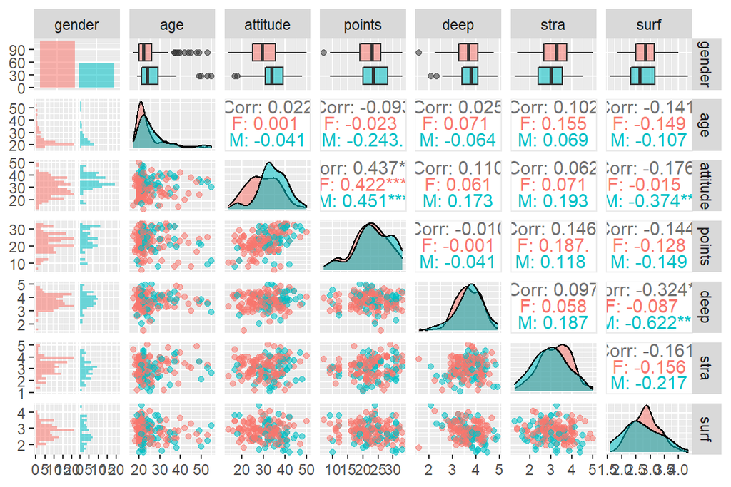

```r
p <- ggpairs(learning2014, mapping = aes(col = gender, alpha = 0.3), lower = list(combo = wrap("facethist", bins = 20)))
p
```

The data includes 110 women and 56 men aged 17 to 55 years (the mean of age is 25.5 years and median 22 years, the distribution of age is positively skewed.) The ranges of other variables are 14-50 (attitude), 7-33 (points), 1.58-4.92 (deep), 1.25-5.00 (stra), 1.58-4.33 (surf). None of the variables seems to have normal distributions. There are moderate correlations between the variables that are statistically significant: attitude is positively correlated with points (r = 0.44). Also the different learning strategies and attitudes, deep, stra and surf, correlate significantly with each other: surf and deep have a negative correlation (r -0.32), and stra and surf also correlate negatively (r = -0.16). Surf and attitude also correlate negatively (r = -.18). There are no significant correlations between age and the other variables. There are some differences between men and women: in fact, surf and attitude correlate statistically significantly only in men (r = -0.37), and not in women (r = -0.02). Surf and deep also correlate actually in men (r = -0.62), but not in women (r = -0.09).

```r
my_model <- lm(points ~ attitude + stra + surf, data = learning2014)
summary(my_model)
```

```
##
## Call:
## lm(formula = points ~ attitude + stra + surf, data = learning2014)
##
## Residuals:
##      Min       1Q   Median       3Q      Max
## -17.1550  -3.4346   0.5156   3.6401  10.8952
##
## Coefficients:
##             Estimate Std. Error t value Pr(>|t|)
## (Intercept) 11.01711    3.68375   2.991  0.00322 **
## attitude     0.33952    0.05741   5.913 1.93e-08 ***
## stra         0.85313    0.54159   1.575  0.11716
## surf        -0.58607    0.80138  -0.731  0.46563
## ---
## Signif. codes:  0 '***' 0.001 '**' 0.01 '*' 0.05 '.' 0.1 ' ' 1
##
## Residual standard error: 5.296 on 162 degrees of freedom
## Multiple R-squared:  0.2074, Adjusted R-squared:  0.1927
## F-statistic: 14.13 on 3 and 162 DF,  p-value: 3.156e-08
```

In a linear regression model with points as the dependent variable and attitude, stra and surf as independent variables, attitude is a statistically significant predictor of points (beta = 0.34, std error = 0.06, p = 1.93*e-08), while stra and surf are not. The estimate for intercept is 11.01 (std. error = 3.68), p = 0.003.

```r
my_model2 <- lm(points ~ attitude + stra, data = learning2014)
summary(my_model2)
```

```
##
## Call:
## lm(formula = points ~ attitude + stra, data = learning2014)
##
## Residuals:
##      Min       1Q   Median       3Q      Max
## -17.6436  -3.3113   0.5575   3.7928  10.9295
##
## Coefficients:
##             Estimate Std. Error t value Pr(>|t|)
## (Intercept)  8.97290    2.39591   3.745  0.00025 ***
## attitude     0.34658    0.05652   6.132 6.31e-09 ***
## stra         0.91365    0.53447   1.709  0.08927 .
## ---
## Signif. codes:  0 '***' 0.001 '**' 0.01 '*' 0.05 '.' 0.1 ' ' 1
##
## Residual standard error: 5.289 on 163 degrees of freedom
## Multiple R-squared:  0.2048, Adjusted R-squared:  0.1951
## F-statistic: 20.99 on 2 and 163 DF,  p-value: 7.734e-09
```

If surf is left out of the model, attitude is still a significant predictor of points, while stra is not.